# countfitteR report

# Overview

Report generated on 2020-08-06 15:26:41.

Detected input file: none.

md5sum of the input file: none

Confidence level: 0.95.

Type of analysis: separate experiments.

Models selected: Poisson, NB, ZIP, ZINB.

## Mean value estimate and its confidence

Counts were fitted to model(s) using the count name as the explanatory variable. The selection of models may be altered using *Settings* panel.

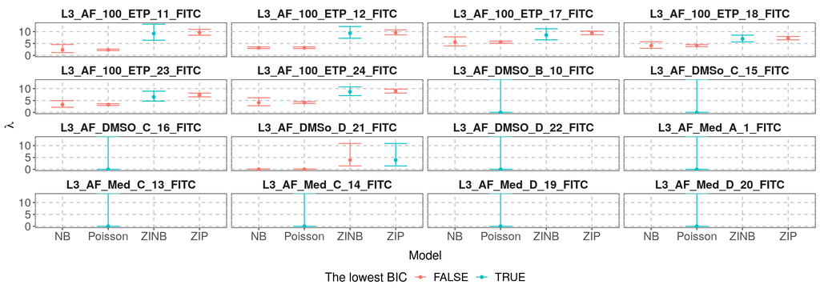

## Summary of estimates

Estimates are presented in the table below along with the BIC values of their models.

| count | lambda | lower | upper | BIC | model |
| --- | --- | --- | --- | --- | --- |
| L3_AF_DMSO_B_10_FITC | 1.38879438649615e-12 | 0 |  | 4.65396035044917 | Poisson |
| L3_AF_100_ETP_11_FITC | 2.32 | 2.03987646235096 | 2.63859115948461 | 898.161807505225 | Poisson |
| L3_AF_100_ETP_12_FITC | 3.21568627496444 | 2.88585379275019 | 3.58321625474317 | 1008.88830906784 | Poisson |
| L3_AF_Med_C_13_FITC | 1.38879438649647e-12 | 0 |  | 4.62497281356758 | Poisson |
| L3_AF_Med_C_14_FITC | 1.38879438649629e-12 | 0 |  | 4.6913478825319 | Poisson |
| L3_AF_DMSo_C_15_FITC | 1.38879438649647e-12 | 0 |  | 4.62497281356758 | Poisson |
| L3_AF_DMSO_C_16_FITC | 1.38879438649647e-12 | 0 |  | 4.62497281356758 | Poisson |
| L3_AF_100_ETP_17_FITC | 5.5714285714286 | 5.13775885690639 | 6.04170362818889 | 1254.78967663566 | Poisson |
| L3_AF_100_ETP_18_FITC | 4.13 | 3.750292680731 | 4.54815169163685 | 852.198139290451 | Poisson |
| L3_AF_Med_D_19_FITC | 3.775134544279e-12 | 0 |  | 3.89182029848059 | Poisson |

[output cut: 54 more lines]

## Coefficients

Estimated coefficients of models (λ for all distributions, θ for NB and ZINB, *r* for ZIP and ZINB).

| count | lambda | theta | r | model |
| --- | --- | --- | --- | --- |
| L3_AF_DMSO_B_10_FITC | 1.38879438649615e-12 |  |  | Poisson |
| L3_AF_100_ETP_11_FITC | 2.32 |  |  | Poisson |
| L3_AF_100_ETP_12_FITC | 3.21568627496444 |  |  | Poisson |
| L3_AF_Med_C_13_FITC | 1.38879438649647e-12 |  |  | Poisson |
| L3_AF_Med_C_14_FITC | 1.38879438649629e-12 |  |  | Poisson |
| L3_AF_DMSo_C_15_FITC | 1.38879438649647e-12 |  |  | Poisson |
| L3_AF_DMSO_C_16_FITC | 1.38879438649647e-12 |  |  | Poisson |
| L3_AF_100_ETP_17_FITC | 5.5714285714286 |  |  | Poisson |
| L3_AF_100_ETP_18_FITC | 4.13 |  |  | Poisson |
| L3_AF_Med_D_19_FITC | 3.775134544279e-12 |  |  | Poisson |

[output cut: 54 more lines]

## Decision

Count name:L3_AF_100_ETP_11_FITC  
The most appropriate model (model with the lowest BIC value): ZINB.  
The evidence that the model with the lowest BIC value is the most appropriate: substantial.  
Count name:L3_AF_100_ETP_12_FITC  
The most appropriate model (model with the lowest BIC value): ZINB.  
The evidence that the model with the lowest BIC value is the most appropriate: strong.  
Count name:L3_AF_100_ETP_17_FITC  
The most appropriate model (model with the lowest BIC value): ZINB.  
The evidence that the model with the lowest BIC value is the most appropriate: substantial.  
Count name:L3_AF_100_ETP_18_FITC  
The most appropriate model (model with the lowest BIC value): ZINB.  
The evidence that the model with the lowest BIC value is the most appropriate: strong.  
Count name:L3_AF_100_ETP_23_FITC  
The most appropriate model (model with the lowest BIC value): ZINB.  
The evidence that the model with the lowest BIC value is the most appropriate: substantial.  
Count name:L3_AF_100_ETP_24_FITC  
The most appropriate model (model with the lowest BIC value): ZINB.  
The evidence that the model with the lowest BIC value is the most appropriate: strong.  
Count name:L3_AF_DMSO_B_10_FITC  
The most appropriate model (model with the lowest BIC value): Poisson.  
The evidence that the model with the lowest BIC value is the most appropriate: NA.  
Count name:L3_AF_DMSo_C_15_FITC  
The most appropriate model (model with the lowest BIC value): Poisson.  
The evidence that the model with the lowest BIC value is the most appropriate: NA.  
Count name:L3_AF_DMSO_C_16_FITC  
The most appropriate model (model with the lowest BIC value): Poisson.  
The evidence that the model with the lowest BIC value is the most appropriate: NA.  
Count name:L3_AF_DMSo_D_21_FITC  
The most appropriate model (model with the lowest BIC value): ZIP.  
The evidence that the model with the lowest BIC value is the most appropriate: substantial.  
Count name:L3_AF_DMSO_D_22_FITC  
The most appropriate model (model with the lowest BIC value): Poisson.  
The evidence that the model with the lowest BIC value is the most appropriate: NA.  
Count name:L3_AF_Med_A_1_FITC  
The most appropriate model (model with the lowest BIC value): Poisson.  
The evidence that the model with the lowest BIC value is the most appropriate: NA.  
Count name:L3_AF_Med_C_13_FITC  
The most appropriate model (model with the lowest BIC value): Poisson.  
The evidence that the model with the lowest BIC value is the most appropriate: NA.  
Count name:L3_AF_Med_C_14_FITC  
The most appropriate model (model with the lowest BIC value): Poisson.  
The evidence that the model with the lowest BIC value is the most appropriate: NA.  
Count name:L3_AF_Med_D_19_FITC  
The most appropriate model (model with the lowest BIC value): Poisson.  
The evidence that the model with the lowest BIC value is the most appropriate: NA.  
Count name:L3_AF_Med_D_20_FITC  
The most appropriate model (model with the lowest BIC value): Poisson.  
The evidence that the model with the lowest BIC value is the most appropriate: NA.

## Compare distributions

Compare an empirical distribution of counts with a distribution defined by the model fitted to counts. Points indicate the real number of counts, while bars the number of counts estimated by a distribution.

[figure not shown]

| count | model | x | n | value |
| --- | --- | --- | --- | --- |
| L3_AF_DMSO_B_10_FITC | Poisson | 0 | 105 | 104.999999999854 |
| L3_AF_DMSO_B_10_FITC | NB | 0 | 105 |  |
| L3_AF_DMSO_B_10_FITC | ZIP | 0 | 105 |  |
| L3_AF_DMSO_B_10_FITC | ZINB | 0 | 105 |  |
| L3_AF_100_ETP_11_FITC | Poisson | 0 | 76 | 9.82735856043618 |
| L3_AF_100_ETP_11_FITC | Poisson | 1 | 2 | 22.7994718602119 |
| L3_AF_100_ETP_11_FITC | Poisson | 2 | 0 | 26.4473873578458 |
| L3_AF_100_ETP_11_FITC | Poisson | 3 | 2 | 20.4526462234007 |
| L3_AF_100_ETP_11_FITC | Poisson | 4 | 5 | 11.8625348095724 |
| L3_AF_100_ETP_11_FITC | Poisson | 5 | 1 | 5.50421615164159 |

[output cut: 782 more lines]

# R Session

**R version 3.6.3 (2020-02-29)**

**Platform:** x86_64-pc-linux-gnu (64-bit)

**locale:** *LC_CTYPE=pl_PL.UTF-8*, *LC_NUMERIC=C*, *LC_TIME=pl_PL.UTF-8*, *LC_COLLATE=pl_PL.UTF-8*, *LC_MONETARY=pl_PL.UTF-8*, *LC_MESSAGES=pl_PL.UTF-8*, *LC_PAPER=pl_PL.UTF-8*, *LC_NAME=C*, *LC_ADDRESS=C*, *LC_TELEPHONE=C*, *LC_MEASUREMENT=pl_PL.UTF-8* and *LC_IDENTIFICATION=C*

**attached base packages:** *stats*, *graphics*, *grDevices*, *utils*, *datasets*, *methods* and *base*

**other attached packages:** *xtable(v.1.8-4)*, *knitr(v.1.29)*, *MASS(v.7.3-51.6)*, *ggplot2(v.3.3.2)*, *rmarkdown(v.2.1)*, *reshape2(v.1.4.3)*, *DT(v.0.11)*, *shinyWidgets(v.0.5.3)*, *shinythemes(v.1.1.2)*, *shiny(v.1.5.0)* and *countfitteR(v.1.2)*

**loaded via a namespace (and not attached):** *Rcpp(v.1.0.5)*, *plyr(v.1.8.5)*, *pillar(v.1.4.3)*, *compiler(v.3.6.3)*, *later(v.1.1.0.1)*, *tools(v.3.6.3)*, *digest(v.0.6.25)*, *jsonlite(v.1.7.0)*, *evaluate(v.0.14)*, *lifecycle(v.0.1.0)*, *tibble(v.2.1.3)*, *gtable(v.0.3.0)*, *pkgconfig(v.2.0.3)*, *rlang(v.0.4.7)*, *rstudioapi(v.0.10)*, *crosstalk(v.1.1.0.1)*, *yaml(v.2.2.1)*, *xfun(v.0.16)*, *fastmap(v.1.0.1)*, *stringr(v.1.4.0)*, *withr(v.2.2.0)*, *dplyr(v.0.8.3)*, *htmlwidgets(v.1.5.1)*, *grid(v.3.6.3)*, *tidyselect(v.0.2.5)*, *glue(v.1.4.1)*, *R6(v.2.4.1)*, *pander(v.0.6.3)*, *farver(v.2.0.3)*, *purrr(v.0.3.3)*, *magrittr(v.1.5)*, *shinycssloaders(v.0.3)*, *scales(v.1.1.0)*, *promises(v.1.1.1)*, *htmltools(v.0.5.0)*, *assertthat(v.0.2.1)*, *mime(v.0.9)*, *colorspace(v.1.4-1)*, *httpuv(v.1.5.4)*, *labeling(v.0.3)*, *stringi(v.1.4.6)*, *pscl(v.1.5.5)*, *munsell(v.0.5.0)*, *markdown(v.1.1)* and *crayon(v.1.3.4)*